# Communicating Effect Sizes to Teachers

6 December 2022

## Slides: bit.ly/WB-06-12

## Background & Focus

### Why designing science communication?

evidence  
informed  
practice

- Teachers: encouraged to consider **evidence** from research (Slavin, 2020)
- Barriers: in their daily practice, they **rarely** draw on research evidence (e.g., Thomm et al., 2021)
- current approaches: toward **teacher-friendly** science communication  
  (Farley-Ripple et al., 2020; Hedges, 2018)

## Background & Focus

### Why looking at effect sizes?

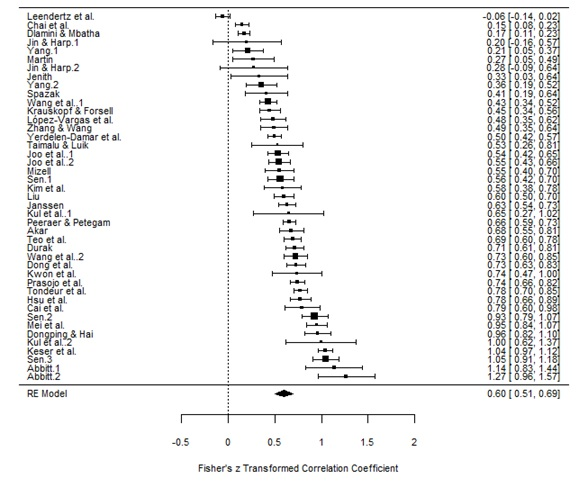

- “**clearing house**” approaches  
  “best available […] evidence from systematic research” (Sackett et al., 1996, p. 71)
- evaluated according to the extent to which it allows to assess **treatment effectiveness** (APA, 2002)
- Meta-analyses demonstrate highest level of evidence  
  ES = **key information** to be communicated (Burns et al., 2011)

## Background & Focus

### Why looking at ES visualizations?

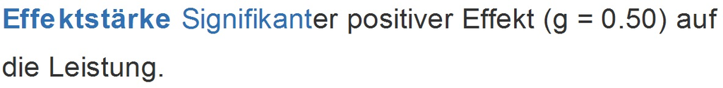

clearinghouse.edu.tum.de

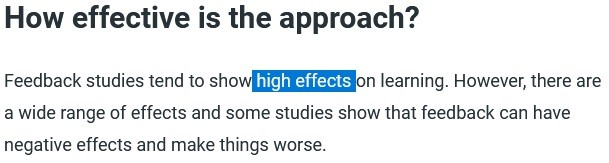

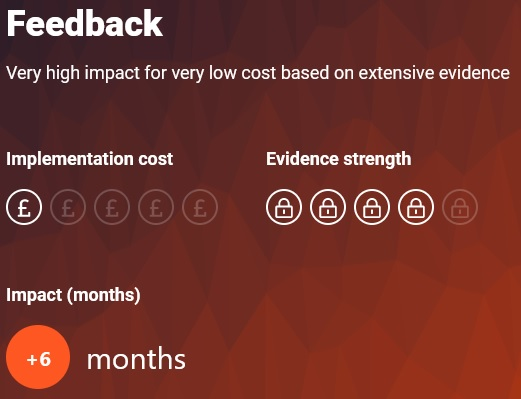

educationendowmentfoundation.org.uk

- scientists & “clearing houses” typically use standardized **textual** representations (Cohen, 1988)
- these are **challenging** for teachers’ sense-making (Hanel et al., 2019; Lortie-Forgues et al., 2021)
- **Translations** of ES (e.g. months of learning) often carry **undesired characteristics** (Baird & Pane, 2019; Kim et al., 2022; Lortie-Forgues et al., 2021)
- Alternative: visualizations (Franconeri et al., 2021)

## Background & Focus

### teacher-friendly communication of ES

**COGNITIVE PROCESSING**

**UNDERSTANDING**

**PERCEPTIONS OF RELEVANCE FOR PRACTICE**

(Jensen & Gerber, 2020)

## Background & Focus

### teacher-friendly communication of ES

**COGNITIVE PROCESSING**  
- task difficulty  
- efficiency

**UNDERSTANDING**

**PERCEPTIONS OF RELEVANCE FOR PRACTICE**

(Korbach et al., 2017; Marcus et al., 1996)

## Background & Focus

### teacher-friendly communication of ES

**COGNITIVE PROCESSING**  
- task difficulty  
- efficiency

**UNDERSTANDING**  
- accuracy  
- sensitivity

**PERCEPTIONS OF RELEVANCE FOR PRACTICE**

(Merk et al., in press)

## Background & Focus

### teacher-friendly communication of ES

**COGNITIVE PROCESSING**  
- task difficulty  
- efficiency

**UNDERSTANDING**  
- accuracy  
- sensitivity

**PERCEPTIONS OF RELEVANCE FOR PRACTICE**  
- perceived informativity  
- perceived value

(Lortie-Forgues et al., 2021)

## Background & Focus

### What we know about visualizing data (for lay people)

**accurately** estimating statistical information: **plot type** plays a role

- box plots: spread; distribution
- bar/line plot: mean
- modified stock chart: maxima, minima; spread (Albers et al., 2014; Pierce & Chick, 2013)

## Background & Focus

### What we know about visualizing data (for lay people)

**accurately** estimating statistical information: **plot type** plays a role

- box plots: spread; distribution
- bar/line plot: mean
- modified stock chart: maxima, minima; spread (Albers et al., 2014; Pierce & Chick, 2013)

**supporting the process**: **enrichment options**

- benchmarks (anchoring) (Cohen, 1988; Jacowitz & Kahneman, 1995)
- cues (signaling) (Schneider et al., 2018)

## Background & Focus

### What we know about visualizing data (for lay people)

- Laypeople are **unimpressed** by plotted ES (McPhetres & Pennycook, 2020)
- adding means to plots increases perception of ES (Kale et al., 2020)

## Background & Focus

### Research interests & Studies

**Delphi-Study**

**Expert judgment** on teacher-friendly plots  
*exploratory*

**Study 1**

Compare **plot types** for their teacher-friendlyness  
*exploratory*

**Study 2**

Compare **enrichment options** for their teacher-friendlyness  
*confirmatory*

## Methods

## Delphi Study

- **4 Experts** in Data Visualization, **4 Experts** in Science Communication
- Phase 1: Collecting **16 plot types**  
  (for group scores on a metric variable)

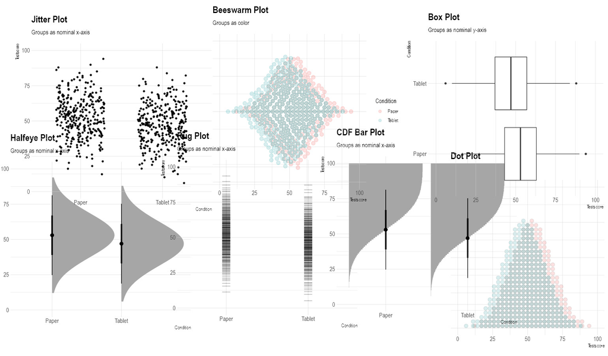

## Delphi Study

- **4 Experts** in Data Visualization, **4 Experts** in Science Communication
- Phase 1: Collecting **16 plot types**  
  (for group scores on a metric variable)
- Phase 2: Rating and Ranking of **44 plots**

*“How accurately might teachers assess the ES depicted in the plot above?”*  
(7-point Likert scale; totally random - totally accurate)

## Delphi Study

- **4 Experts** in Data Visualization, **4 Experts** in Science Communication
- Phase 1: Collecting **16 plot types**  
  (for group scores on a metric variable)
- Phase 2: Rating and Ranking of **44 plots**

*“How accurately might teachers assess the ES depicted in the plot above?”*  
(7-point Likert scale; totally random - totally accurate)

**Results: Top ranked types**

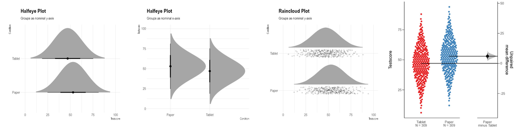

## Study 1

### plot types: Design

Does **visualization type** affect understanding, cognitive processing and perceptions of relevance?

Which **visualization types** produce the most desirable ratings?

- in-service **teachers** (N = 40)
- **4 x 6** within-design
  - 4 plot types
  - 6 ES (*d*= -.8 to .8)
- **randomizations**
  - order of conditions
  - vignettes (1 of 4 randomized between)

## Study 1

### plot types: Measures

| construct | example_item | source |
| --- | --- | --- |
| Perceived task difficulty | How difficult was it for you to understand the figure? | (Marcus et al., 1996) |
| Efficiency | [time taken to answer sensitivity and accuracy] | own creation |
| Sensitivity | Is one group superior to the other or are they approximately the same? | (Merk et al., in press) |
| Accuracy | How much percent of the groups will overlap on the test score? | own creation |
| Perceived informativity | How informative do you perceive the way the information is presented in the figure? | (Lortie-Forgues et al., 2021) |
| Perceived value | To what extent are these results relevant for your future teaching? | own creation |

Demo: es-vis-demo1.formr.org

## Study 1

### plot types: Results ICCs

Bayes factor analyses testing  
\(H1: ICC = 0\)  
\(H2: ICC > 0\)  
\(H3: complement\)

- Accuracy:
  - Cliff’s Delta: inconclusive
  - Overlap: inconclusive
  - Cohen’s U3: inconclusive
- Sensitivity
- Task Difficulty: \(BF_{21}=7.896*10^6; BF_{23}=Inf\)
- Informativity: \(BF_{21}=85.355; BF_{23}=Inf\)
- Value: \(BF_{21}=174.388; BF_{23}=Inf\)

## Study 1

### plot types: Results, Descriptives

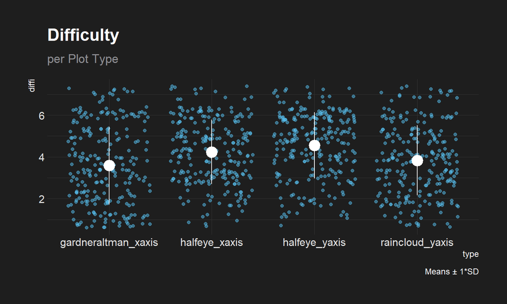

## Study 1

### plot types: Results, Descriptives

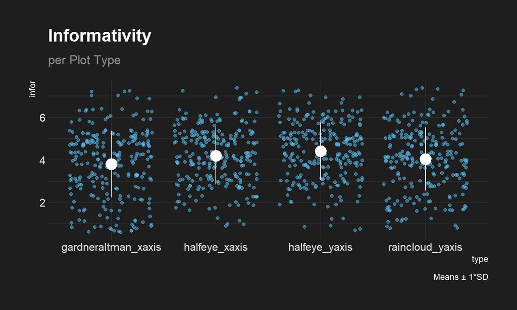

## Study 1

### plot types: Results, Descriptives

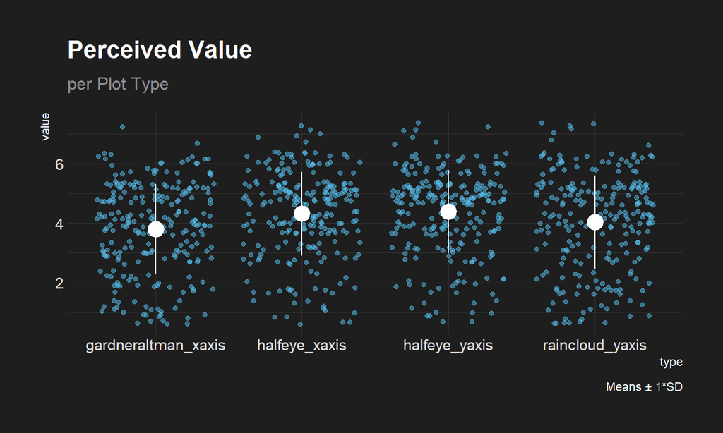

## Study 1

### plot types: Results accuracy

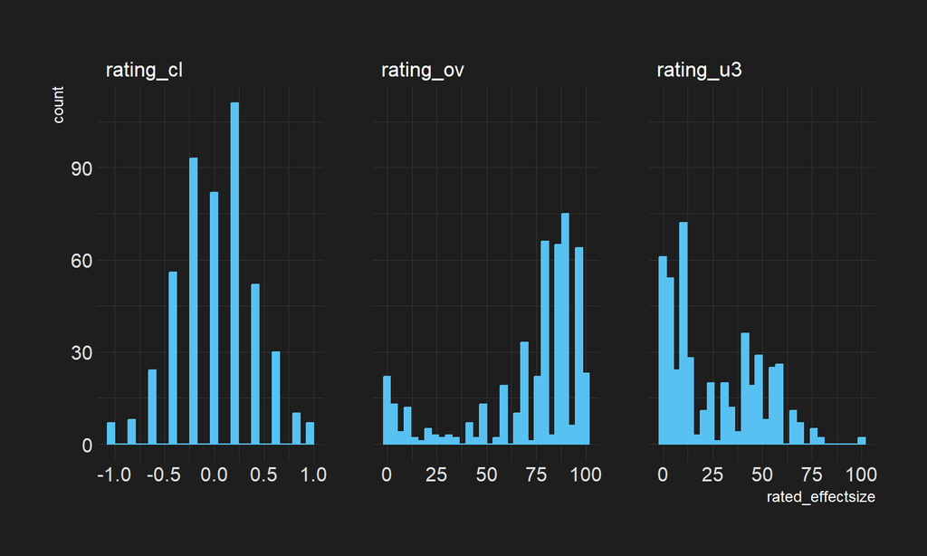

## Study 1

### plot types: Results accuracy

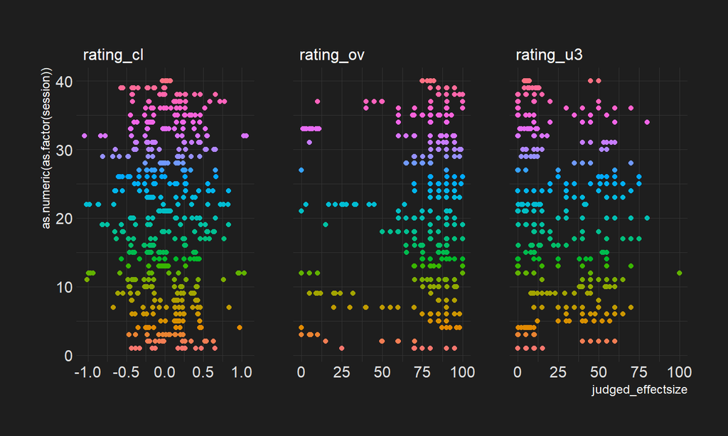

## Study 1

### plot types: Results accuracy

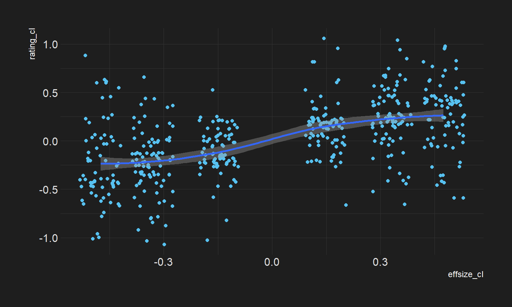

## Study 1

### plot types: Results accuracy

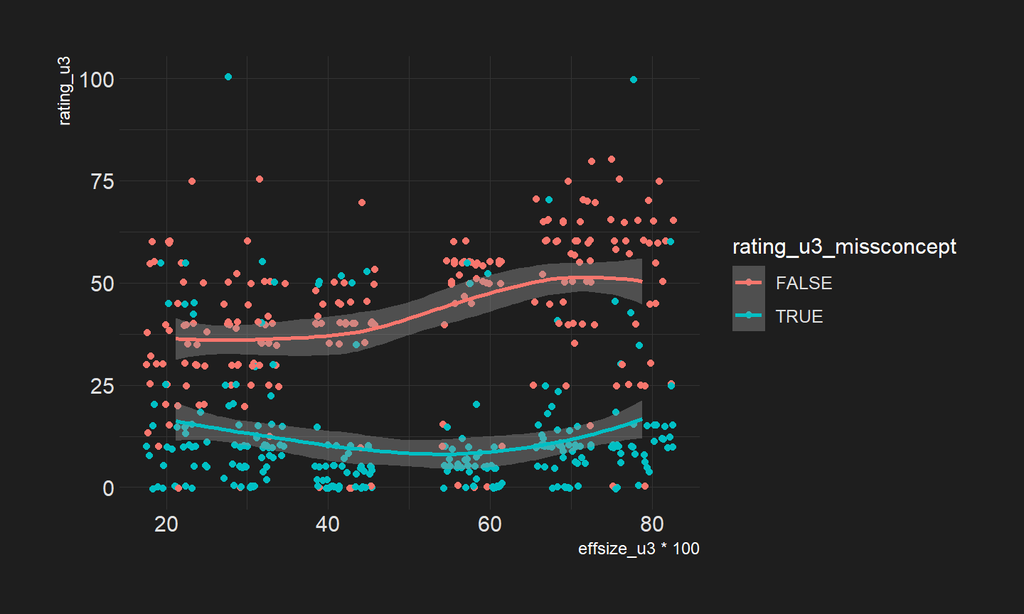

## Study 1

### plot types: Results accuracy

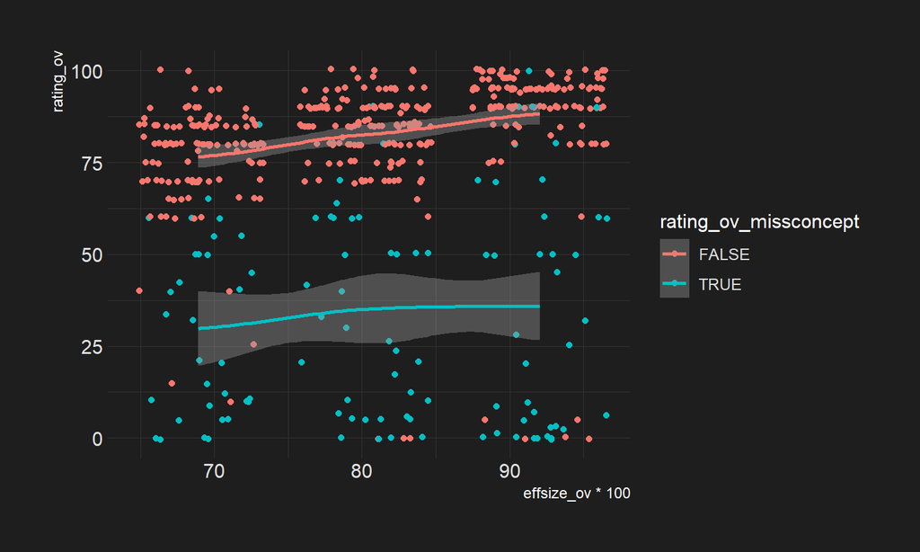

## Study 1

### plot types: Results accuracy

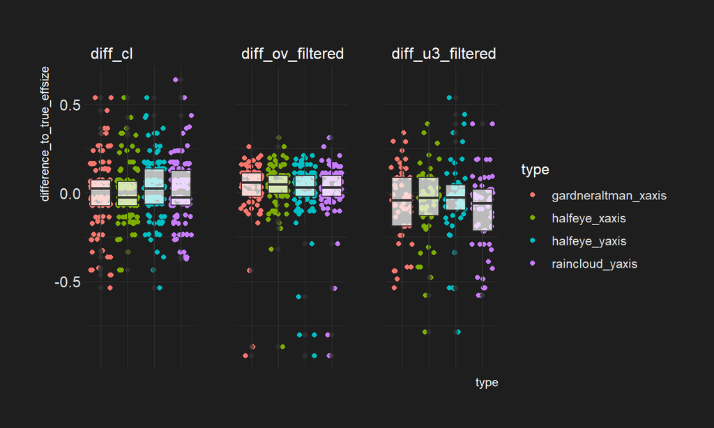

without misconceptions

## Study 1

### plot types: Results efficiency

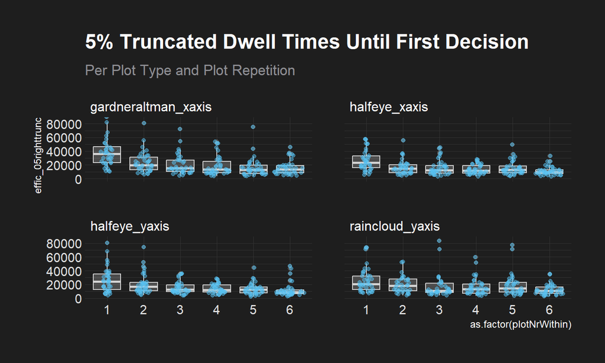

## Study 2

### Enrichment options: Design

How do plots with **visual benchmarks** affect the outcomes, compared to plots without benchmarks?

How do plots with **signaling** affect the outcomes compared to plots without signaling?

- in-service **teachers** (N = Bayesian updating)
- **2 RCTs**
  - Factor: visual benchmarking (yes vs. no)
  - Factor: signaling (difference, overlap, no signaling)

## Study 2

### Enrichment options: Design

[figure not shown]

## Study 2

### Enrichment options: Design

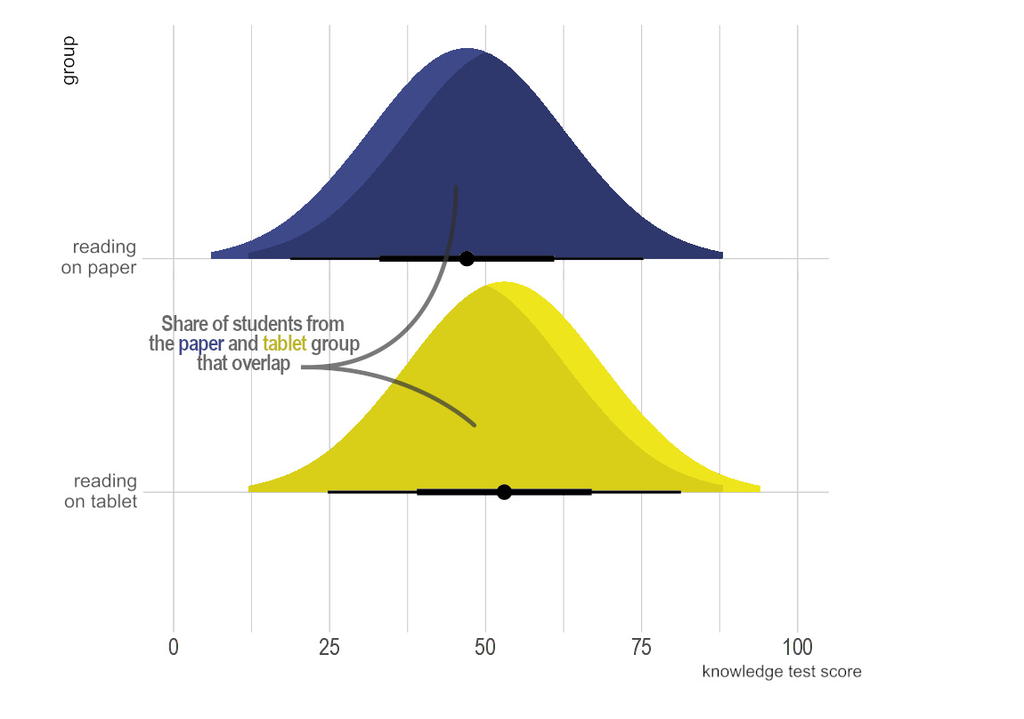

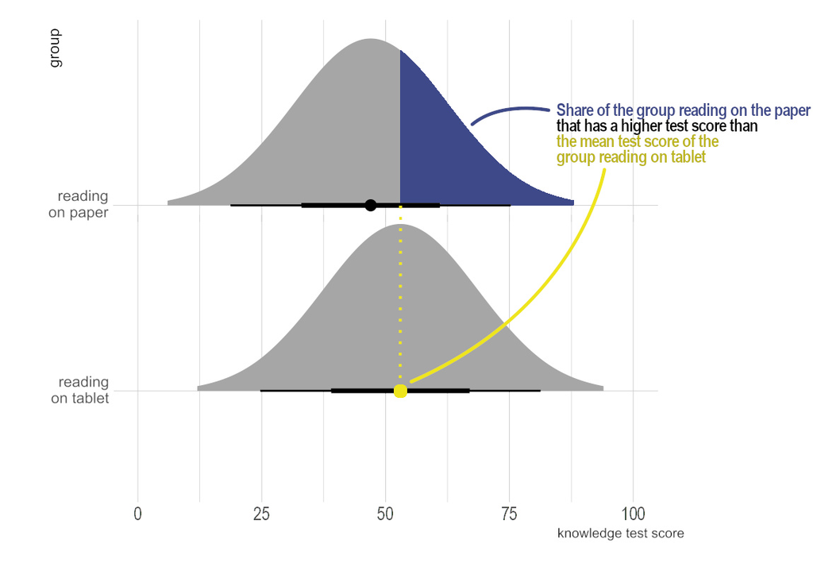

## Current progress

## Current progress

### and further plans

- **Delphi-Study** completed
- Self-generated **measures** piloted
- **Study 1** completed
- Registered Report:
  - structured abstract
  - stage 1 report
  - stage 2 report
- Planned: conceptual replication with **student teachers**

## Questions

### beyond general feedback

- We are piloting the items on U3 and Overlap once again: Do you have any suggestions for precise wording?
- Are there any plot types or enrichment options that you think would be interesting?
- Would a decision-task be interesting? (trade-off: will take up a lot of time in the survey)

## Thank you

[figure not shown]

**Jürgen Schneider**  
ju.schneider@dipf.de

**Cooperation**

[figure not shown]

**Slides**: bit.ly/WB-06-12

Albers, D., Correll, M., & Gleicher, M. (2014). Task-driven evaluation of aggregation in time series visualization. *Proceedings of the SIGCHI Conference on Human Factors in Computing Systems*, 551–560. https://doi.org/10.1145/2556288.2557200

APA. (2002). Criteria for evaluating treatment guidelines. *American Psychologist*, *57*(12), 1052–1059. https://doi.org/10.1037/0003-066X.57.12.1052

Baird, M. D., & Pane, J. F. (2019). Translating Standardized Effects of Education Programs Into More Interpretable Metrics. *Educational Researcher*, *48*(4), 217–228. https://doi.org/10.3102/0013189X19848729

Burns, P. B., Rohrich, R. J., & Chung, K. C. (2011). The levels of evidence and their role in evidence-based medicine. *Plastic and Reconstructive Surgery*, *128*(1), 305–310. https://doi.org/10.1097/PRS.0b013e318219c171

Cohen, J. (1988). *Statistical Power Analysis for the Behavioral Sciences* (2nd ed.). Taylor; Francis. http://gbv.eblib.com/patron/FullRecord.aspx?p=1192162

Farley-Ripple, E. N., Oliver, K., & Boaz, A. (2020). Mapping the community: Use of research evidence in policy and practice. *Humanities and Social Sciences Communications*, *7*(1), 83. https://doi.org/10.1057/s41599-020-00571-2

Franconeri, S. L., Padilla, L. M., Shah, P., Zacks, J. M., & Hullman, J. (2021). The Science of Visual Data Communication: What Works. *Psychological Science in the Public Interest*, *22*(3), 110–161. https://doi.org/10.1177/15291006211051956

Hanel, P. H. P., Maio, G. R., & Manstead, A. S. R. (2019). A new way to look at the data: Similarities between groups of people are large and important. *Journal of Personality and Social Psychology*, *116*(4), 541–562. https://doi.org/10.1037/pspi0000154

Hedges, L. V. (2018). Challenges in Building Usable Knowledge in Education. *Journal of Research on Educational Effectiveness*, *11*(1), 1–21. https://doi.org/10.1080/19345747.2017.1375583

Hoijtink, H., Mulder, J., Lissa, C. van, & Gu, X. (2019). A tutorial on testing hypotheses using the Bayes factor. *Psychological Methods*. https://doi.org/10.1037/met0000201

Jacowitz, K. E., & Kahneman, D. (1995). Measures of Anchoring in Estimation Tasks. *Personality and Social Psychology Bulletin*, *21*(11), 1161–1166. https://doi.org/10.1177/01461672952111004

Jensen, E. A., & Gerber, A. (2020). Evidence- Based Science Communication. *Frontiers in Communication*, *4*, 78. https://doi.org/10.3389/fcomm.2019.00078

Kale, A., Kay, M., & Hullman, J. (2020). *Visual Reasoning Strategies for Effect Size Judgments and Decisions*. https://doi.org/10.48550/ARXIV.2007.14516

Kim, Y.-S., Hofman, J. M., & Goldstein, D. G. (2022). Putting scientific results in perspective: Improving the communication of standardized effect sizes. *CHI Conference on Human Factors in Computing Systems*, 1–14. https://doi.org/10.1145/3491102.3502053

Korbach, A., Brünken, R., & Park, B. (2017). Measurement of cognitive load in multimedia learning: A comparison of different objective measures. *Instructional Science*, *45*(4), 515–536. https://doi.org/10.1007/s11251-017-9413-5

Lortie-Forgues, H., Sio, U. N., & Inglis, M. (2021). How Should Educational Effects Be Communicated to Teachers? *Educational Researcher*, 0013189X2098785. https://doi.org/10.3102/0013189X20987856

Marcus, N., Cooper, M., & Sweller, J. (1996). Understanding instructions. *Journal of Educational Psychology*, *88*(1), 49–63. https://doi.org/10.1037/0022-0663.88.1.49

McPhetres, J., & Pennycook, G. (2020). *Lay people are unimpressed by the effect sizes typically reported in psychological science* [Preprint]. PsyArXiv. https://doi.org/10.31234/osf.io/qu9hn

Pierce, R., & Chick, H. (2013). Workplace statistical literacy for teachers: Interpreting box plots. *Mathematics Education Research Journal*, *25*(2), 189–205. https://doi.org/10.1007/s13394-012-0046-3

Sackett, D. L., Rosenberg, W. M. C., Gray, J. A. M., Haynes, R. B., & Richardson, W. S. (1996). Evidence based medicine: What it is and what it isn’t. *BMJ*, *312*(7023), 71–72. https://doi.org/10.1136/bmj.312.7023.71

Schneider, S., Beege, M., Nebel, S., & Rey, G. D. (2018). A meta-analysis of how signaling affects learning with media. *Educational Research Review*, *23*, 1–24. https://doi.org/10.1016/j.edurev.2017.11.001

Slavin, R. E. (2020). How evidence-based reform will transform research and practice in education. *Educational Psychologist*, *55*(1), 21–31. https://doi.org/10.1080/00461520.2019.1611432

Thomm, E., Gold, B., Betsch, T., & Bauer, J. (2021). When preservice teachers’ prior beliefs contradict evidence from educational research. *British Journal of Educational Psychology*. https://doi.org/10.1111/bjep.12407

**Icons:**

Icons by Font Awesome CC BY 4.0

## Background & Focus

### What we know about visualizing data (in general)

## Cumulative Link Model

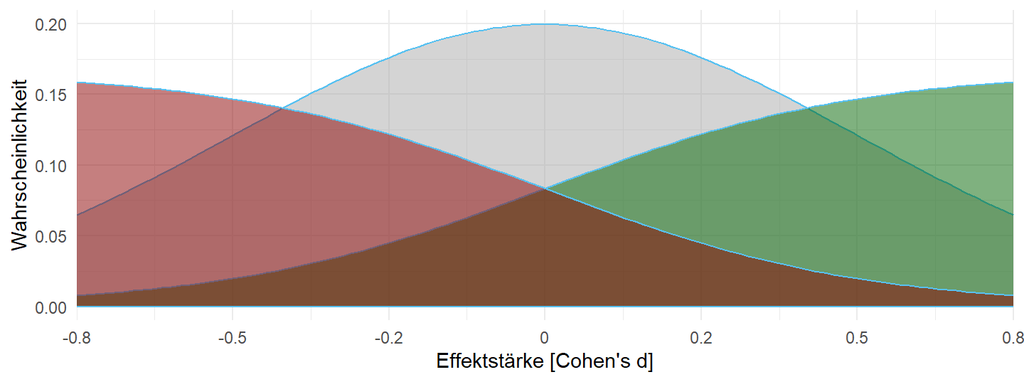

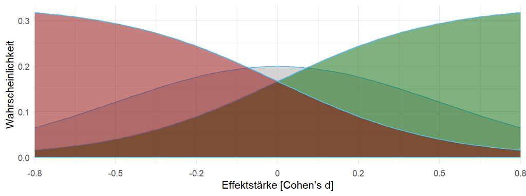

## Study 2

### plot types: Measures

same as Study 1

| construct | example_item | source |
| --- | --- | --- |
| Perceived task difficulty | How difficult was it for you to understand the figure? | (Marcus et al., 1996) |
| Efficiency | [time taken to answer sensitivity and accuracy] | own creation |
| Sensitivity | Is one group superior to the other or are they approximately the same? | (Merk et al., in press) |
| Accuracy | How much percent of the groups will overlap on the test score? | own creation |
| Perceived informativity | How informative do you perceive the way the information is presented in the figure? | (Lortie-Forgues et al., 2021) |
| Perceived value | To what extent are these results relevant for your future teaching? | own creation |

## Study 2

### Statistical Analyses

- approximate adjusted fractional Bayes factors (Hoijtink et al., 2019)

**Benchmarking**

H3.1: \(\mu(sens)_{noBench} < \mu(sens)_{Bench}\)

H3.2: \(\mu(acc)_{noBench} < \mu(acc)_{Bench}\)

H3.3: \(\mu(inf)_{noBench} < \mu(inf)_{Bench}\)

H3.4: \(\mu(diff)_{noBench} > \mu(diff)_{Bench}\)

## Study 2

### Statistical Analyses

- approximate adjusted fractional Bayes factors (Hoijtink et al., 2019)

**Textual Cues**

H4.1: \((\mu(sens)_{VisOnly} , \mu(sens)_{TextOnly}) < \mu(sens)_{Vis+Text}\)

H4.2: \((\mu(acc)_{VisOnly} , \mu(acc)_{TextOnly}) < \mu(acc)_{Vis+Text}\)

H4.3: \((\mu(inf)_{VisOnly} , \mu(inf)_{TextOnly}) < \mu(inf)_{Vis+Text}\)

H4.4: \((\mu(diff)_{VisOnly} , \mu(diff)_{TextOnly}) > \mu(diff)_{Vis+Text}\)